# Convolutional Neural Networks

## Project: Write an Algorithm for a Dog Identification App

In this notebook, some template code has already been provided for you, and you will need to implement additional functionality to successfully complete this project. You will not need to modify the included code beyond what is requested. Sections that begin with **'(IMPLEMENTATION)'** in the header indicate that the following block of code will require additional functionality which you must provide. Instructions will be provided for each section, and the specifics of the implementation are marked in the code block with a 'TODO' statement. Please be sure to read the instructions carefully!

> **Note**: Once you have completed all of the code implementations, you need to finalize your work by exporting the Jupyter Notebook as an HTML document. Before exporting the notebook to html, all of the code cells need to have been run so that reviewers can see the final implementation and output. You can then export the notebook by using the menu above and navigating to **File -> Download as -> HTML (.html)**. Include the finished document along with this notebook as your submission.

In addition to implementing code, there will be questions that you must answer which relate to the project and your implementation. Each section where you will answer a question is preceded by a **'Question X'** header. Carefully read each question and provide thorough answers in the following text boxes that begin with **'Answer:'**. Your project submission will be evaluated based on your answers to each of the questions and the implementation you provide.

> **Note:** Code and Markdown cells can be executed using the **Shift + Enter** keyboard shortcut. Markdown cells can be edited by double-clicking the cell to enter edit mode.

The rubric contains *optional* "Stand Out Suggestions" for enhancing the project beyond the minimum requirements. If you decide to pursue the "Stand Out Suggestions", you should include the code in this Jupyter notebook.

### Why We're Here

In this notebook, you will make the first steps towards developing an algorithm that could be used as part of a mobile or web app. At the end of this project, your code will accept any user-supplied image as input. If a dog is detected in the image, it will provide an estimate of the dog's breed. If a human is detected, it will provide an estimate of the dog breed that is most resembling. The image below displays potential sample output of your finished project (... but we expect that each student's algorithm will behave differently!).

[figure not shown]

In this real-world setting, you will need to piece together a series of models to perform different tasks; for instance, the algorithm that detects humans in an image will be different from the CNN that infers dog breed. There are many points of possible failure, and no perfect algorithm exists. Your imperfect solution will nonetheless create a fun user experience!

### The Road Ahead

We break the notebook into separate steps. Feel free to use the links below to navigate the notebook.

- Step 0: Import Datasets
- Step 1: Detect Humans
- Step 2: Detect Dogs
- Step 3: Create a CNN to Classify Dog Breeds (from Scratch)
- Step 4: Create a CNN to Classify Dog Breeds (using Transfer Learning)
- Step 5: Write your Algorithm
- Step 6: Test Your Algorithm

## Step 0: Import Datasets

Make sure that you've downloaded the required human and dog datasets:

**Note: if you are using the Udacity workspace, you *DO NOT* need to re-download these - they can be found in the `/data` folder as noted in the cell below.**

- Download the [dog dataset](https://s3-us-west-1.amazonaws.com/udacity-aind/dog-project/dogImages.zip). Unzip the folder and place it in this project's home directory, at the location `/dog_images`.
- Download the [human dataset](https://s3-us-west-1.amazonaws.com/udacity-aind/dog-project/lfw.zip). Unzip the folder and place it in the home directory, at location `/lfw`.

*Note: If you are using a Windows machine, you are encouraged to use [7zip](http://www.7-zip.org/) to extract the folder.*

In the code cell below, we save the file paths for both the human (LFW) dataset and dog dataset in the numpy arrays `human_files` and `dog_files`.

```python
# Mount Drive
from google.colab import drive
drive.mount( '/content/drive' )
```

```python
import numpy as np
from glob import glob

# load filenames for human and dog images
human_files = np.array( glob("/content/drive/My Drive/Udacity-Intro to Pytorch/Convolutional Neural \
Networks/project-dog-classification/lfw/*/*") )
dog_files = np.array( glob("/content/drive/My Drive/Udacity-Intro to Pytorch/Convolutional Neural \
Networks/project-dog-classification/dogImages/dogImages/*/*/*/*") )

# print number of images in each dataset
print('There are %d total human images.' % len(human_files))
print('There are %d total dog images.' % len(dog_files))
```

```
There are 13233 total human images.
There are 8351 total dog images.
```

```python
dog_data_pth = '/content/drive/My Drive/Udacity-Intro to Pytorch/Convolutional Neural \
Networks/project-dog-classification/dogImages/dogImages/dogImages/'

train_files = np.array( glob(dog_data_pth + "train/*/*") )
valid_files = np.array( glob(dog_data_pth + "valid/*/*") )
test_files = np.array( glob(dog_data_pth + "test/*/*") )

print(" Num of Train Images: ", len(train_files), "\n",\
      "Num of Validation Images: ", len(valid_files), "\n",\
      "Num of Test Images: ", len(test_files))
```

```
 Num of Train Images:  6680
 Num of Validation Images:  835
 Num of Test Images:  836
```

## Step 1: Detect Humans

In this section, we use OpenCV's implementation of [Haar feature-based cascade classifiers](http://docs.opencv.org/trunk/d7/d8b/tutorial_py_face_detection.html) to detect human faces in images.

OpenCV provides many pre-trained face detectors, stored as XML files on [github](https://github.com/opencv/opencv/tree/master/data/haarcascades). We have downloaded one of these detectors and stored it in the `haarcascades` directory. In the next code cell, we demonstrate how to use this detector to find human faces in a sample image.

```
Number of faces detected: 1
```

[figure not shown]

```python
import cv2
import matplotlib.pyplot as plt
%matplotlib inline

# extract pre-trained face detector
face_cascade = cv2.CascadeClassifier( '/content/drive/My Drive/Udacity-Intro to Pytorch/Convolutional Neural \
Networks/project-dog-classification/haarcascades/haarcascade_frontalface_alt.xml' )

def get_faces( img_file ):
    """This function returns an RGB image
    and the number of faces detected in an image.
        **args: path to an image
    """
    # load color (BGR) image
    img = cv2.imread( img_file )
    # convert BGR image to grayscale
    gray = cv2.cvtColor( img, cv2.COLOR_BGR2GRAY )

    # find faces in image
    faces = face_cascade.detectMultiScale( gray )

    # print number of faces detected in the image
    #print('Number of faces detected:', len(faces))

    # get bounding box for each detected face
    for ( x,y,w,h ) in faces:
        # add bounding box to color image
        cv2.rectangle( img,(x,y),(x+w,y+h),(255,0,0),2 )

    # convert BGR image to RGB for plotting
    cv_rgb = cv2.cvtColor( img, cv2.COLOR_BGR2RGB )
    return cv_rgb, faces

def show_img( img_file ):
    """This function visualizes images from the face
    detector algorithm
        **args: path to an image
    """
    img, faces = get_faces( img_file )

    # print number of faces detected in the image
    print( 'Number of faces detected:', len(faces) )
    # display the image, along with bounding box
    plt.imshow(img)
    plt.show()

show_img(human_files[0])
```

Before using any of the face detectors, it is standard procedure to convert the images to grayscale. The `detectMultiScale` function executes the classifier stored in `face_cascade` and takes the grayscale image as a parameter.

In the above code, `faces` is a numpy array of detected faces, where each row corresponds to a detected face. Each detected face is a 1D array with four entries that specifies the bounding box of the detected face. The first two entries in the array (extracted in the above code as `x` and `y`) specify the horizontal and vertical positions of the top left corner of the bounding box. The last two entries in the array (extracted here as `w` and `h`) specify the width and height of the box.

### Write a Human Face Detector

We can use this procedure to write a function that returns `True` if a human face is detected in an image and `False` otherwise. This function, aptly named `face_detector`, takes a string-valued file path to an image as input and appears in the code block below.

```python
# returns "True" if face is detected in image stored at img_path
def face_detector( img_path ):
    """This fuction detects the presence or absence
    of face(s) in an image
        **args: path to an image
        **returns: (bool) True/False
    """
    img = cv2.imread( img_path )
    gray = cv2.cvtColor( img, cv2.COLOR_BGR2GRAY )
    faces = face_cascade.detectMultiScale( gray )
    if len( faces ) > 0:
        return True
    else:
        return False
```

### (IMPLEMENTATION) Assess the Human Face Detector

**Question 1:** Use the code cell below to test the performance of the `face_detector` function.

- What percentage of the first 100 images in `human_files` have a detected human face?
- What percentage of the first 100 images in `dog_files` have a detected human face?

Ideally, we would like 100% of human images with a detected face and 0% of dog images with a detected face. You will see that our algorithm falls short of this goal, but still gives acceptable performance. We extract the file paths for the first 100 images from each of the datasets and store them in the numpy arrays `human_files_short` and `dog_files_short`.

**Answer:** (You can print out your results and/or write your percentages in this cell)

```python
from tqdm import tqdm_notebook
import warnings
warnings.filterwarnings( 'ignore' )

human_files_short = human_files[:100]
dog_files_short = dog_files[:100]

#-#-# Do NOT modify the code above this line. #-#-#

## TODO: Test the performance of the face_detector algorithm
## on the images in human_files_short and dog_files_short.
file_len = len( dog_files_short )

## loop through the files and detect images with faces
# for human data
human_pure_data = []
dog_human_data = []

for ii in tqdm_notebook( range(file_len) ):
    if face_detector(human_files_short[ii]) == True:
        human_pure_data.append(human_files_short[ii])
    if face_detector(dog_files_short[ii]) == False:
        dog_human_data.append(dog_files_short[ii])


# Answering the question.......
h_num_w_faces = len( human_pure_data )
d_num_w_faces = file_len - len( dog_human_data )
print('Answer:')
print("The percentage of the first 100 images in the human_files with detected faces is", h_num_w_faces/file_len * 100, "%")
print()
print("The percentage of the first 100 images in the dog_files with detected faces is", d_num_w_faces/file_len * 100, "%")
```

```
Answer:
The percentage of the first 100 images in the human_files with detected faces is 99.0 %

The percentage of the first 100 images in the dog_files with detected faces is 7.000000000000001 %
```

```python
# Getting samples of mis detected images
dogs_w_faces = []
humans_wo_faces = []

for ii in tqdm_notebook(range(file_len)):
    if face_detector(human_files_short[ii]) == False:
        humans_wo_faces.append(human_files_short[ii])
    if face_detector(dog_files_short[ii]) == True:
        dogs_w_faces.append(dog_files_short[ii])
```

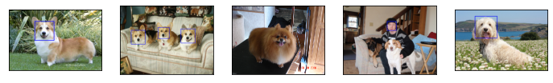

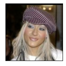

```python
# show few samples of images with failed jobs

def imshow( file, range_ ):
    """Helper funtion to visualize images
        **args: file - image
        **      range_ - number of images to visualize
    """
    # visualize all images
    fig = plt.figure(figsize=(12, 12))
    for i in range(range_):
        if len(file) > i:
            ax = fig.add_subplot(1, range_, i+1, xticks=[], yticks=[])
            img, _ = get_faces(file[i])
            ax.imshow(img)
imshow( dogs_w_faces, 5 )
imshow( humans_wo_faces, 5 )
```

**Observation:**

> We can see that although the algorithm detected some of the dog faces wrongly as human faces, it did see a human face in some of the dog images.

We suggest the face detector from OpenCV as a potential way to detect human images in your algorithm, but you are free to explore other approaches, especially approaches that make use of deep learning :). Please use the code cell below to design and test your own face detection algorithm. If you decide to pursue this *optional* task, report performance on `human_files_short` and `dog_files_short`.

```python
### (Optional)
### TODO: Test performance of anotherface detection algorithm.
### Feel free to use as many code cells as needed.
```

## Step 2: Detect Dogs

In this section, we use a [pre-trained model](http://pytorch.org/docs/master/torchvision/models.html) to detect dogs in images.

### Obtain Pre-trained VGG-16 Model

The code cell below downloads the VGG-16 model, along with weights that have been trained on [ImageNet](http://www.image-net.org/), a very large, very popular dataset used for image classification and other vision tasks. ImageNet contains over 10 million URLs, each linking to an image containing an object from one of [1000 categories](https://gist.github.com/yrevar/942d3a0ac09ec9e5eb3a).

```python
import torch
import torchvision.models as models
torch.manual_seed(42)

# define VGG16 model
VGG16 = models.vgg16(pretrained=True)

# check if CUDA is available
use_cuda = torch.cuda.is_available()
print(use_cuda)

# move model to GPU if CUDA is available
if use_cuda:
    VGG16 = VGG16.cuda()
```

```
Downloading: "https://download.pytorch.org/models/vgg16-397923af.pth" to /root/.cache/torch/hub/checkpoints/vgg16-397923af.pth
```

```
True
```

Given an image, this pre-trained VGG-16 model returns a prediction (derived from the 1000 possible categories in ImageNet) for the object that is contained in the image.

### (IMPLEMENTATION) Making Predictions with a Pre-trained Model

In the next code cell, you will write a function that accepts a path to an image (such as `'dogImages/train/001.Affenpinscher/Affenpinscher_00001.jpg'`) as input and returns the index corresponding to the ImageNet class that is predicted by the pre-trained VGG-16 model. The output should always be an integer between 0 and 999, inclusive.

Before writing the function, make sure that you take the time to learn how to appropriately pre-process tensors for pre-trained models in the [PyTorch documentation](http://pytorch.org/docs/stable/torchvision/models.html).

```python
from PIL import Image
import torchvision.transforms as transforms

# Set PIL to be tolerant of image files that are truncated.
from PIL import ImageFile
ImageFile.LOAD_TRUNCATED_IMAGES = True

def model_predict( img_path, model ):
    '''
    Use pre-trained VGG-16 model to obtain index corresponding to
    predicted ImageNet class for image at specified path

    Args:
        img_path: path to an image
        model: trained classifier

    Returns:
        Index corresponding to VGG-16 model's prediction
    '''

    ## TODO: Complete the function.
    ## Load and pre-process an image from the given img_path
    ## Return the *index* of the predicted class for that image
    # Load in the image and convert to rgb
    img = Image.open(img_path).convert('RGB')

    # transforming image
    transform = transforms.Compose([transforms.Resize(256),
                                   transforms.CenterCrop(224),
                                   transforms.ToTensor(),
                                   transforms.Normalize(mean=[0.485, 0.456, 0.406],#see https://pytorch.org/docs/stable/torchvision/models.html
                                                         std=[0.229, 0.224, 0.225])])#for how they are obtained from the images
    img = transform(img)

    # move model to cuda if available
    if use_cuda:
        model = model.cuda()
        img = img.cuda()
    else:
        model = model.cpu()

    # Unsqueezing to add artificial dimension
    img = img.unsqueeze(0)

    # getting predictions, set model to evaluation
    model.eval()
    with torch.no_grad():
        output = model.forward(img)
        output = output.cpu()

    prediction, predicted_class_idx = torch.max(output, 1)

    return predicted_class_idx # predicted class index
```

### (IMPLEMENTATION) Write a Dog Detector

While looking at the [dictionary](https://gist.github.com/yrevar/942d3a0ac09ec9e5eb3a), you will notice that the categories corresponding to dogs appear in an uninterrupted sequence and correspond to dictionary keys 151-268, inclusive, to include all categories from `'Chihuahua'` to `'Mexican hairless'`. Thus, in order to check to see if an image is predicted to contain a dog by the pre-trained VGG-16 model, we need only check if the pre-trained model predicts an index between 151 and 268 (inclusive).

Use these ideas to complete the `dog_detector` function below, which returns `True` if a dog is detected in an image (and `False` if not).

```python
### returns "True" if a dog is detected in the image stored at img_path
def dog_detector( img_path, model ):
    """This fuction detects the presence or absence
    of a dog in an image
        **args: img_path - path to an image
                model - trained classifier

        **returns: (bool) True/False
    """
    ## TODO: Complete the function.
    dog_label = model_predict( img_path, model )
    if dog_label in torch.LongTensor( np.arange(151, 269, 1) ):
        return True
    else:
        return False # true/false
```

### (IMPLEMENTATION) Assess the Dog Detector

**Question 2:** Use the code cell below to test the performance of your `dog_detector` function.

- What percentage of the images in `human_files_short` have a detected dog?
- What percentage of the images in `dog_files_short` have a detected dog?

**Answer:** (Answer is printed with the cell below)

```python
### TODO: Test the performance of the dog_detector function
### on the images in human_files_short and dog_files_short.
# loop through data to detect dogs only in data
dog_pure_data = []
human_dog_data = []
print('Detecting with the VGG16 model ........')
for ii in tqdm_notebook(range(file_len)):
    if dog_detector(human_files_short[ii], VGG16) == False:
        human_dog_data.append(human_files_short[ii])
    if dog_detector(dog_files_short[ii], VGG16) == True:
        dog_pure_data.append(dog_files_short[ii])

# get images with failed jobs
dog_impure_data = []
human_dog_data_1 = []

for ii in tqdm_notebook(range(file_len)):
    if dog_detector(human_files_short[ii], VGG16) == True:
        human_dog_data_1.append(human_files_short[ii])
    if dog_detector(dog_files_short[ii], VGG16) == False:
        dog_impure_data.append(dog_files_short[ii])


# Answering the question.......
dog_imgs = len(dog_pure_data)
imgs_w_humans = file_len - len(human_dog_data)
print('Answer:')
print("The percentage of images in the human_files_short with a detected dog is", imgs_w_humans/file_len * 100, "%")
print()
print("The percentage of the first 100 images in the dog_files with a detected dog is", dog_imgs/file_len * 100, "%")
```

```
Detecting with the VGG16 model ........
```

```
Answer:
The percentage of images in the human_files_short with a detected dog is 1.0 %

The percentage of the first 100 images in the dog_files with a detected dog is 99.0 %
```

We suggest VGG-16 as a potential network to detect dog images in your algorithm, but you are free to explore other pre-trained networks (such as [Inception-v3](http://pytorch.org/docs/master/torchvision/models.html#inception-v3), [ResNet-50](http://pytorch.org/docs/master/torchvision/models.html#id3), etc). Please use the code cell below to test other pre-trained PyTorch models. If you decide to pursue this *optional* task, report performance on `human_files_short` and `dog_files_short`.

```python
### (Optional)
### TODO: Report the performance of another pre-trained network.
### Feel free to use as many code cells as needed.
# defining a ResNet-50 model
ResNet = models.resnet50(pretrained=True)

# check if CUDA is available
use_cuda = torch.cuda.is_available()

# move model to GPU if CUDA is available
if use_cuda:
    ResNet = ResNet.cuda()
```

```
Downloading: "https://download.pytorch.org/models/resnet50-19c8e357.pth" to /root/.cache/torch/hub/checkpoints/resnet50-19c8e357.pth
```

```python
dog_pure_data_res = []
human_dog_data_res = []

print('Detecting with the ResNet-50 model ........')
for ii in tqdm_notebook(range(file_len)):
    if dog_detector(human_files_short[ii], ResNet) == False:
        human_dog_data_res.append(human_files_short[ii])
    if dog_detector(dog_files_short[ii], ResNet) == True:
        dog_pure_data_res.append(dog_files_short[ii])


# get images with failed jobs
dog_impure_data_res = []
human_dog_data_1_res = []

for ii in tqdm_notebook(range(file_len)):
    if dog_detector(human_files_short[ii], ResNet) == True:
        human_dog_data_1_res.append(human_files_short[ii])
    if dog_detector(dog_files_short[ii], ResNet) == False:
        dog_impure_data_res.append(dog_files_short[ii])

# Answering the question.......
dog_imgs = len(dog_pure_data_res)
imgs_w_humans = file_len - len(human_dog_data_res)
print("The percentage of the first 100 images in the human_files with a detected dog is", imgs_w_humans/file_len * 100, "%")
print()
print("The percentage of the first 100 images in the dog_files with a detected dog is", dog_imgs/file_len * 100, "%")
```

```
Detecting with the ResNet-50 model ........
```

```
The percentage of the first 100 images in the human_files with a detected dog is 1.0 %

The percentage of the first 100 images in the dog_files with a detected dog is 99.0 %
```

## Step 3: Create a CNN to Classify Dog Breeds (from Scratch)

Now that we have functions for detecting humans and dogs in images, we need a way to predict breed from images. In this step, you will create a CNN that classifies dog breeds. You must create your CNN *from scratch* (so, you can't use transfer learning *yet*!), and you must attain a test accuracy of at least 10%. In Step 4 of this notebook, you will have the opportunity to use transfer learning to create a CNN that attains greatly improved accuracy.

We mention that the task of assigning breed to dogs from images is considered exceptionally challenging. To see why, consider that *even a human* would have trouble distinguishing between a Brittany and a Welsh Springer Spaniel.

| Brittany | Welsh Springer Spaniel |
| --- | --- |

It is not difficult to find other dog breed pairs with minimal inter-class variation (for instance, Curly-Coated Retrievers and American Water Spaniels).

| Curly-Coated Retriever | American Water Spaniel |
| --- | --- |

Likewise, recall that labradors come in yellow, chocolate, and black. Your vision-based algorithm will have to conquer this high intra-class variation to determine how to classify all of these different shades as the same breed.

| Yellow Labrador | Chocolate Labrador | Black Labrador |
| --- | --- | --- |

We also mention that random chance presents an exceptionally low bar: setting aside the fact that the classes are slightly imabalanced, a random guess will provide a correct answer roughly 1 in 133 times, which corresponds to an accuracy of less than 1%.

Remember that the practice is far ahead of the theory in deep learning. Experiment with many different architectures, and trust your intuition. And, of course, have fun!

### (IMPLEMENTATION) Specify Data Loaders for the Dog Dataset

Use the code cell below to write three separate [data loaders](http://pytorch.org/docs/stable/data.html#torch.utils.data.DataLoader) for the training, validation, and test datasets of dog images (located at `dog_images/train`, `dog_images/valid`, and `dog_images/test`, respectively). You may find [this documentation on custom datasets](http://pytorch.org/docs/stable/torchvision/datasets.html) to be a useful resource. If you are interested in augmenting your training and/or validation data, check out the wide variety of [transforms](http://pytorch.org/docs/stable/torchvision/transforms.html?highlight=transform)!

```python
import os
from torchvision import datasets
torch.manual_seed(42)

### TODO: Write data loaders for training, validation, and test sets
## Specify appropriate transforms, and batch_sizes
data_dir = '/content/drive/My Drive/Udacity-Intro to Pytorch/Convolutional Neural \
Networks/project-dog-classification/dogImages/dogImages/dogImages/'
train_dir = data_dir + 'train'
test_dir = data_dir + 'test'
valid_dir = data_dir + 'valid'

# transform jobs with data augmentation only for the train data
transform = {'train':transforms.Compose([transforms.RandomHorizontalFlip(),
                                        transforms.RandomRotation(45),
                                        transforms.RandomResizedCrop(224),
                                        transforms.ToTensor(),
                                        transforms.Normalize(mean=[0.485, 0.456, 0.406],
                                                             std=[0.229, 0.224, 0.225])]),
            'test':transforms.Compose([transforms.Resize(256),
                                      transforms.CenterCrop(224),
                                      transforms.ToTensor(),
                                      transforms.Normalize(mean=[0.485, 0.456, 0.406],
                                                             std=[0.229, 0.224, 0.225])])}

# Obtaining the datasets
datasets = {'train':datasets.ImageFolder(root=train_dir, transform=transform['train']),
           'test':datasets.ImageFolder(root=test_dir, transform=transform['test']),
           'valid':datasets.ImageFolder(root=valid_dir, transform=transform['test'])}

# Preparing dataloaders
batch_size = 16
num_workers = 0 # number of subprocesses to use for data loading

loaders_scratch = {'train':torch.utils.data.DataLoader(datasets['train'], batch_size=batch_size, shuffle=True, num_workers=num_workers),
                  'test':torch.utils.data.DataLoader(datasets['test'], batch_size=batch_size),
                  'valid':torch.utils.data.DataLoader(datasets['valid'], batch_size=batch_size)}

print('DataLoaders specified successfully!')
print('Number of Dog Breeds in Dataset:', len(os.listdir(train_dir)))
```

```
DataLoaders specified successfully!
Number of Dog Breeds in Dataset: 133
```

**Question 3:** Describe your chosen procedure for preprocessing the data.

- How does your code resize the images (by cropping, stretching, etc)? What size did you pick for the input tensor, and why?
- Did you decide to augment the dataset? If so, how (through translations, flips, rotations, etc)? If not, why not?

**Answer**:

> - I used **`torch.transforms.Resize()`** to scale and **`torch.transforms.CenterCrop()`** to crop the images. I picked 224 for the input tensor because most of the pretrained models (which were trained on the imagenet) accept 224 as input size.
> - Yes, I augmented the dataset. I did so through HorizontalFlipping and RandomRotations in 45 degrees.

### (IMPLEMENTATION) Model Architecture

Create a CNN to classify dog breed. Use the template in the code cell below.

```python
import torch.nn as nn
import torch.nn.functional as F
from torchsummary import summary
from IPython.display import display, Image

# define the CNN architecture
class Net(nn.Module):
    ### TODO: choose an architecture, and complete the class
    def __init__( self ):
        super( Net, self ).__init__()
        ## Define layers of a CNN

        # convolutional layer (sees 224x224x3 image tensor)
        self.conv1 = nn.Conv2d( 3, 16, 3, padding=1 )
        # convolutional layer (sees 112x12x16 tensor)
        self.conv2 = nn.Conv2d( 16, 32, 3, padding=1 )
        # convolutional layer (sees 56x56x32 tensor)
        self.conv3 = nn.Conv2d( 32, 64, 3, padding=1 )
        # convolutional layer (sees 28x28x64 tensor)
        self.conv4 = nn.Conv2d( 64, 128, 3, padding=1 )
        # convolutional layer (sees 14x14x128 tensor)
        self.conv5 = nn.Conv2d( 128, 256, 3, padding=1 )

        # max pooling layer
        self.pool1 = nn.MaxPool2d( 2, 2 )
        self.pool2 = nn.MaxPool2d( 2, 4 )

        # linear layer (256 * 4 * 4 -> 2048)
        self.fc1 = nn.Linear( 256 * 4 * 4, 2048 )
        # linear layer (2048 -> 1024)
        self.fc2 = nn.Linear( 2048, 1024 )
        # linear layer (1024 -> 500)
        self.fc3 = nn.Linear( 1024, 500 )
        # linear layer (500 -> 133)
        self.fc4 = nn.Linear( 500, 133 ) # Num of classes = 133

        # Batch Norm conv
        self.conv1_bn = nn.BatchNorm2d(16)
        self.conv2_bn = nn.BatchNorm2d(32)
        self.conv3_bn = nn.BatchNorm2d(64)
        self.conv4_bn = nn.BatchNorm2d(128)
        self.conv5_bn = nn.BatchNorm2d(256)

        # Batch Norm linear
        self.fc1_bn = nn.BatchNorm1d(2048)
        self.fc2_bn = nn.BatchNorm1d(1024)
        self.fc3_bn = nn.BatchNorm1d(500)


        # dropout layer (p=0.25)
        self.dropout1 = nn.Dropout(0.25)
        # dropout layer (p=0.15)
        self.dropout2 = nn.Dropout(0.15)


    def forward( self, x ):
        ## Define forward behavior
        x = self.pool1( F.relu(self.conv1_bn(self.conv1(x))) )
        x = self.pool1( F.relu(self.conv2_bn(self.conv2(x))) )
        x = self.pool1( F.relu(self.conv3_bn(self.conv3(x))) )
        x = self.pool1( F.relu(self.conv4_bn(self.conv4(x))) )
        x = self.pool2( F.relu(self.conv5_bn(self.conv5(x))) )


        # flatten image input
        x = x.view(-1, 256 * 4 * 4)

        # add 1st hidden layer, with relu activation function
        x = F.relu( self.fc1_bn(self.fc1(x)) )
        # add dropout layer
        x = self.dropout2(x)
        # add 2nd hidden layer, with relu activation function
        x = F.relu( self.fc2_bn(self.fc2(x)) )
        # add dropout layer
        x = self.dropout1(x)
        # add 3rd hidden layer, with relu activation function
        x = F.relu( self.fc3_bn(self.fc3(x)) )
        # add dropout layer
        x = self.dropout1(x)
        # add 4th hidden layer
        x = self.fc4(x)
        return x

#-#-# You do NOT have to modify the code below this line. #-#-#

# instantiate the CNN
model_scratch = Net()

# move tensors to GPU if CUDA is available
use_cuda = True
if use_cuda:
    model_scratch.cuda()
display(summary(model_scratch, (3, 224, 224)))
```

```
----------------------------------------------------------------
        Layer (type)               Output Shape         Param #
================================================================
            Conv2d-1         [-1, 16, 224, 224]             448
       BatchNorm2d-2         [-1, 16, 224, 224]              32
         MaxPool2d-3         [-1, 16, 112, 112]               0
            Conv2d-4         [-1, 32, 112, 112]           4,640
       BatchNorm2d-5         [-1, 32, 112, 112]              64
         MaxPool2d-6           [-1, 32, 56, 56]               0
            Conv2d-7           [-1, 64, 56, 56]          18,496
       BatchNorm2d-8           [-1, 64, 56, 56]             128
         MaxPool2d-9           [-1, 64, 28, 28]               0
           Conv2d-10          [-1, 128, 28, 28]          73,856
      BatchNorm2d-11          [-1, 128, 28, 28]             256
        MaxPool2d-12          [-1, 128, 14, 14]               0
           Conv2d-13          [-1, 256, 14, 14]         295,168
      BatchNorm2d-14          [-1, 256, 14, 14]             512
        MaxPool2d-15            [-1, 256, 4, 4]               0
           Linear-16                 [-1, 2048]       8,390,656
      BatchNorm1d-17                 [-1, 2048]           4,096
          Dropout-18                 [-1, 2048]               0
           Linear-19                 [-1, 1024]       2,098,176
      BatchNorm1d-20                 [-1, 1024]           2,048
          Dropout-21                 [-1, 1024]               0
           Linear-22                  [-1, 500]         512,500
      BatchNorm1d-23                  [-1, 500]           1,000
          Dropout-24                  [-1, 500]               0
           Linear-25                  [-1, 133]          66,633
================================================================
Total params: 11,468,709
Trainable params: 11,468,709
Non-trainable params: 0
----------------------------------------------------------------
Input size (MB): 0.57
Forward/backward pass size (MB): 26.72
Params size (MB): 43.75
Estimated Total Size (MB): 71.04
----------------------------------------------------------------
```

```
None
```

**Question 4:** Outline the steps you took to get to your final CNN architecture and your reasoning at each step.

**Answer:**

> - Firstly, I defined the convolutional layers which were five (5) in number, with initial depth 3, which is the RGB color channels of the input image, and a `kernel_size` of (3, 3), `stride` and `padding` initialized with the default value of 1.
> - Secondly, I defined two pooling layers, one of stride=pool=2 and another of stride=4 and pool=2, these layers help reduce the resolution of the feature maps by computing the max value over small windows.
> - Thirdly, I defined the fully connected layers, which takes in the flattened output of the convolution and pooling layers.
> - I defined Batch Normalizers for individual layers. Batch normalizers helps model generalize.
> - Next, I created dropout layers which taken in a probability of $0.15$ and $0.25$ to turn of nodes during training and avoid overfitting.
> - Then I created a forward process using the layers I have defined with a $Relu$ activation function.

### (IMPLEMENTATION) Specify Loss Function and Optimizer

Use the next code cell to specify a [loss function](http://pytorch.org/docs/stable/nn.html#loss-functions) and [optimizer](http://pytorch.org/docs/stable/optim.html). Save the chosen loss function as `criterion_scratch`, and the optimizer as `optimizer_scratch` below.

```python
import torch.optim as optim

### TODO: select loss function
criterion_scratch = nn.CrossEntropyLoss()

### TODO: select optimizer
optimizer_scratch = optim.SGD(model_scratch.parameters(), lr=0.01)
```

### (IMPLEMENTATION) Train and Validate the Model

Train and validate your model in the code cell below. [Save the final model parameters](http://pytorch.org/docs/master/notes/serialization.html) at filepath `'model_scratch.pt'`.

```python
# the following import is required for training to be robust to truncated images
from PIL import ImageFile
ImageFile.LOAD_TRUNCATED_IMAGES = True

def train(n_epochs, loaders, model, optimizer, criterion, use_cuda, save_path):
    """returns trained model"""
    # initialize tracker for minimum validation loss and list of train and valid losses
    valid_loss_min = np.Inf
    epochs = list(np.arange(1, n_epochs+1, 1))
    train_losses = {'total':[], 'batch':[]}
    valid_losses = {'total':[], 'batch':[]}
    accuracy = {'train':[], 'valid':[]}

    for epoch in range(1, n_epochs+1):
        # initialize variables to monitor training and validation loss
        train_loss = valid_loss = correct = total = total_valid = 0.0
        running_loss_train = running_loss_valid = correct_valid = 0.0


        ###################
        # train the model #
        ###################
        model.train()
        for batch_idx, (data, target) in enumerate(loaders['train']):
            # move to GPU
            if use_cuda:
                data, target = data.cuda(), target.cuda()
            ## find the loss and update the model parameters accordingly
             # clear the gradients of all optimized variables
            optimizer.zero_grad()
            # forward pass: compute predicted outputs by passing inputs to the model
            output = model(data)
            # calculate the batch loss
            loss = criterion(output, target)
            # backward pass: compute gradient of the loss with respect to model parameters
            loss.backward()
            # perform a single optimization step (parameter update)
            optimizer.step()
            ## record the average training loss, using something like
            train_loss = train_loss + ((1 / (batch_idx + 1)) * (loss.data - train_loss))
            # convert output probabilities to predicted class
            pred = output.data.max(1, keepdim=True)[1]
            # compare predictions to true label
            correct += np.sum(np.squeeze(pred.eq(target.data.view_as(pred))).cpu().numpy())
            total += data.size(0)

            ## loss statistics
            running_loss_train += loss.item()
            if batch_idx % 10 == 9:
                avg_loss = running_loss_train/10
                train_losses['batch'].append(avg_loss)
                running_loss_train = 0.0


        ######################
        # validate the model #
        ######################
        model.eval()
        for batch_idx, (data, target) in enumerate(loaders['valid']):
            # move to GPU
            if use_cuda:
                data, target = data.cuda(), target.cuda()
            ## update the average validation loss
            # forward pass: compute predicted outputs by passing inputs to the model
            output = model(data)
            # calculate the batch loss
            loss = criterion(output, target)
            # update average validation loss
            valid_loss = valid_loss + ((1 / (batch_idx + 1))) * (loss.data - valid_loss)
            # convert output probabilities to predicted class
            pred = output.data.max(1, keepdim=True)[1]
            # compare predictions to true label
            correct_valid += np.sum(np.squeeze(pred.eq(target.data.view_as(pred))).cpu().numpy())
            total_valid += data.size(0)

            ## loss statistics
            running_loss_valid += loss.item()

            if batch_idx % 10 == 9: # get loss after ten batches
                avg_loss = running_loss_valid/10
                valid_losses['batch'].append(avg_loss)
                running_loss_valid = 0.0

        # tracking total losses
        train_losses['total'].append(train_loss.cpu().numpy())
        valid_losses['total'].append(valid_loss.cpu().numpy())
        accuracy['train'].append(100. * correct/total)
        accuracy['valid'].append(100. * correct_valid/total_valid)
        # print training/validation statistics
        print('Epoch: {} \tTraining Loss: {:.6f} \tValidation Loss: {:.6f}'.format(
            epoch,
            train_loss,
            valid_loss
            ))

        ## TODO: save the model if validation loss has decreased
        if valid_loss <= valid_loss_min:
            print('Validation loss decreased ({:.6f} --> {:.6f}).  Saving model ...'.format(
            valid_loss_min,
            valid_loss))
            torch.save(model.state_dict(), save_path)
            valid_loss_min = valid_loss

    # return trained model
    return model, [train_losses, valid_losses, accuracy]
```

```python
# Defining model path
model_path = '/content/drive/My Drive/Udacity-Intro to Pytorch/Convolutional \
Neural Networks/project-dog-classification/'
```

```python
# train the model
%time
model_scratch, scratch_metrics = train(200, loaders_scratch, model_scratch, optimizer_scratch,
                      criterion_scratch, use_cuda, model_path+'model_scratch.pt')
```

```
CPU times: user 2 µs, sys: 0 ns, total: 2 µs
Wall time: 4.53 µs
Epoch: 1 	Training Loss: 4.684977 	Validation Loss: 4.493219
Validation loss decreased (inf --> 4.493219).  Saving model ...
Epoch: 2 	Training Loss: 4.546623 	Validation Loss: 4.302786
Validation loss decreased (4.493219 --> 4.302786).  Saving model ...
Epoch: 3 	Training Loss: 4.426564 	Validation Loss: 4.254175
Validation loss decreased (4.302786 --> 4.254175).  Saving model ...
Epoch: 4 	Training Loss: 4.353143 	Validation Loss: 4.209390
Validation loss decreased (4.254175 --> 4.209390).  Saving model ...
Epoch: 5 	Training Loss: 4.288677 	Validation Loss: 4.068373
Validation loss decreased (4.209390 --> 4.068373).  Saving model ...
Epoch: 6 	Training Loss: 4.228588 	Validation Loss: 4.012761
Validation loss decreased (4.068373 --> 4.012761).  Saving model ...
Epoch: 7 	Training Loss: 4.158640 	Validation Loss: 4.020077
Epoch: 8 	Training Loss: 4.110168 	Validation Loss: 3.895593
Validation loss decreased (4.012761 --> 3.895593).  Saving model ...
Epoch: 9 	Training Loss: 4.058885 	Validation Loss: 4.007403
Epoch: 10 	Training Loss: 4.018338 	Validation Loss: 4.196227
Epoch: 11 	Training Loss: 3.978986 	Validation Loss: 3.842127
Validation loss decreased (3.895593 --> 3.842127).  Saving model ...
Epoch: 12 	Training Loss: 3.941593 	Validation Loss: 3.879629
Epoch: 13 	Training Loss: 3.909826 	Validation Loss: 3.646532
Validation loss decreased (3.842127 --> 3.646532).  Saving model ...
Epoch: 14 	Training Loss: 3.880429 	Validation Loss: 3.696733
Epoch: 15 	Training Loss: 3.831648 	Validation Loss: 3.634278
Validation loss decreased (3.646532 --> 3.634278).  Saving model ...
Epoch: 16 	Training Loss: 3.804039 	Validation Loss: 3.562104
Validation loss decreased (3.634278 --> 3.562104).  Saving model ...
Epoch: 17 	Training Loss: 3.781088 	Validation Loss: 3.815639
Epoch: 18 	Training Loss: 3.779501 	Validation Loss: 3.606108
Epoch: 19 	Training Loss: 3.708537 	Validation Loss: 3.489223
Validation loss decreased (3.562104 --> 3.489223).  Saving model ...
Epoch: 20 	Training Loss: 3.708102 	Validation Loss: 3.879397
Epoch: 21 	Training Loss: 3.675095 	Validation Loss: 3.775158
Epoch: 22 	Training Loss: 3.665522 	Validation Loss: 3.455734
Validation loss decreased (3.489223 --> 3.455734).  Saving model ...
Epoch: 23 	Training Loss: 3.613718 	Validation Loss: 3.405552
Validation loss decreased (3.455734 --> 3.405552).  Saving model ...
Epoch: 24 	Training Loss: 3.601551 	Validation Loss: 3.311006
```

[output cut: 191 more lines]

```
Epoch: 186 	Training Loss: 1.796270 	Validation Loss: 2.171466
Epoch: 187 	Training Loss: 1.785323 	Validation Loss: 2.602563
Epoch: 188 	Training Loss: 1.784313 	Validation Loss: 2.145122
Epoch: 189 	Training Loss: 1.790878 	Validation Loss: 2.105678
Epoch: 190 	Training Loss: 1.753581 	Validation Loss: 2.228122
Epoch: 191 	Training Loss: 1.762411 	Validation Loss: 2.098441
Epoch: 192 	Training Loss: 1.742404 	Validation Loss: 2.108835
Epoch: 193 	Training Loss: 1.752119 	Validation Loss: 2.159039
Epoch: 194 	Training Loss: 1.731502 	Validation Loss: 2.079946
Epoch: 195 	Training Loss: 1.761524 	Validation Loss: 2.129673
Epoch: 196 	Training Loss: 1.707332 	Validation Loss: 2.187880
Epoch: 197 	Training Loss: 1.736456 	Validation Loss: 2.456722
Epoch: 198 	Training Loss: 1.729043 	Validation Loss: 2.217134
Epoch: 199 	Training Loss: 1.737067 	Validation Loss: 2.134745
Epoch: 200 	Training Loss: 1.723227 	Validation Loss: 2.337100
```

```python
# load the model that got the best validation accuracy
model_scratch.load_state_dict(torch.load(model_path+'model_scratch.pt'))
```

```
<All keys matched successfully>
```

```python
# Getting metrics

total_loss_t = scratch_metrics[0]['total']
total_loss_v = scratch_metrics[1]['total']
train_acc = scratch_metrics[2]['train']
valid_acc = scratch_metrics[2]['valid']
```

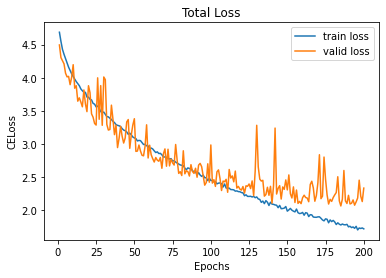

```python
epochs = np.arange(1, 201, 1)
plt.plot(epochs, total_loss_t, label='train loss')
plt.plot(epochs, total_loss_v, label='valid loss')
plt.title('Total Loss')
plt.xlabel('Epochs')
plt.ylabel('CELoss')
plt.legend();
```

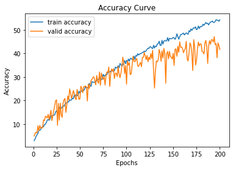

```python
epochs = np.arange(1, 201, 1)
plt.plot(epochs, train_acc, label='train accuracy')
plt.plot(epochs, valid_acc, label='valid accuracy')
plt.title('Accuracy Curve')
plt.xlabel('Epochs')
plt.ylabel('Accuracy')
plt.legend();
```

### (IMPLEMENTATION) Test the Model

Try out your model on the test dataset of dog images. Use the code cell below to calculate and print the test loss and accuracy. Ensure that your test accuracy is greater than 10%.

```python
def test(loaders, model, criterion, use_cuda):

    # monitor test loss and accuracy
    test_loss = 0.
    correct = 0.
    total = 0.

    model.eval()
    for batch_idx, (data, target) in enumerate(loaders['test']):
        # move to GPU
        if use_cuda:
            data, target = data.cuda(), target.cuda()
        # forward pass: compute predicted outputs by passing inputs to the model
        output = model(data)
        # calculate the loss
        loss = criterion(output, target)
        # update average test loss
        test_loss = test_loss + ((1 / (batch_idx + 1)) * (loss.data - test_loss))
        # convert output probabilities to predicted class
        pred = output.data.max(1, keepdim=True)[1]
        # compare predictions to true label
        correct += np.sum(np.squeeze(pred.eq(target.data.view_as(pred))).cpu().numpy())
        total += data.size(0)

    print('Test Loss: {:.6f}\n'.format(test_loss))

    print('\nTest Accuracy: %2d%% (%2d/%2d)' % (
        100. * correct / total, correct, total))
```

```python
# call test function
%time

test(loaders_scratch, model_scratch, criterion_scratch, use_cuda)
```

[output not shown]

## Step 4: Create a CNN to Classify Dog Breeds (using Transfer Learning)

You will now use transfer learning to create a CNN that can identify dog breed from images. Your CNN must attain at least 60% accuracy on the test set.

### (IMPLEMENTATION) Specify Data Loaders for the Dog Dataset

Use the code cell below to write three separate [data loaders](http://pytorch.org/docs/master/data.html#torch.utils.data.DataLoader) for the training, validation, and test datasets of dog images (located at `dogImages/train`, `dogImages/valid`, and `dogImages/test`, respectively).

If you like, **you are welcome to use the same data loaders from the previous step**, when you created a CNN from scratch.

```python
## TODO: Specify data loaders
# getting previously defined dataloders
loaders_transfer = loaders_scratch.copy()
```

### (IMPLEMENTATION) Model Architecture

Use transfer learning to create a CNN to classify dog breed. Use the code cell below, and save your initialized model as the variable `model_transfer`.

```python
import torchvision.models as models
import torch.nn as nn

## TODO: Specify model architecture
model_transfer = models.vgg16(pretrained=True)

# I will be using feature extraction method so I only want the initalized model_parameters to be updated
for param in model_transfer.parameters():
    param.requires_grad = False


model_transfer.classifier
```

```
Sequential(
  (0): Linear(in_features=25088, out_features=4096, bias=True)
  (1): ReLU(inplace=True)
  (2): Dropout(p=0.5, inplace=False)
  (3): Linear(in_features=4096, out_features=4096, bias=True)
  (4): ReLU(inplace=True)
  (5): Dropout(p=0.5, inplace=False)
  (6): Linear(in_features=4096, out_features=1000, bias=True)
)
```

```python
# Updating the extracted parameters
net = nn.Sequential(
        nn.Linear(25088, 4096),
        nn.ReLU(),
        nn.Dropout(p=0.1),
        nn.Linear(4096, 1000),
        nn.ReLU(),
        nn.Dropout(p=0.15),
        nn.Linear(1000, 133),
        nn.LogSoftmax(dim=1))

model_transfer.classifier = net

if use_cuda:
    model_transfer = model_transfer.cuda()

summary(model_transfer, (3, 224, 224))
```

```
----------------------------------------------------------------
        Layer (type)               Output Shape         Param #
================================================================
            Conv2d-1         [-1, 64, 224, 224]           1,792
              ReLU-2         [-1, 64, 224, 224]               0
            Conv2d-3         [-1, 64, 224, 224]          36,928
              ReLU-4         [-1, 64, 224, 224]               0
         MaxPool2d-5         [-1, 64, 112, 112]               0
            Conv2d-6        [-1, 128, 112, 112]          73,856
              ReLU-7        [-1, 128, 112, 112]               0
            Conv2d-8        [-1, 128, 112, 112]         147,584
              ReLU-9        [-1, 128, 112, 112]               0
        MaxPool2d-10          [-1, 128, 56, 56]               0
           Conv2d-11          [-1, 256, 56, 56]         295,168
             ReLU-12          [-1, 256, 56, 56]               0
           Conv2d-13          [-1, 256, 56, 56]         590,080
             ReLU-14          [-1, 256, 56, 56]               0
           Conv2d-15          [-1, 256, 56, 56]         590,080
             ReLU-16          [-1, 256, 56, 56]               0
        MaxPool2d-17          [-1, 256, 28, 28]               0
           Conv2d-18          [-1, 512, 28, 28]       1,180,160
             ReLU-19          [-1, 512, 28, 28]               0
           Conv2d-20          [-1, 512, 28, 28]       2,359,808
             ReLU-21          [-1, 512, 28, 28]               0
           Conv2d-22          [-1, 512, 28, 28]       2,359,808
             ReLU-23          [-1, 512, 28, 28]               0
        MaxPool2d-24          [-1, 512, 14, 14]               0
           Conv2d-25          [-1, 512, 14, 14]       2,359,808
             ReLU-26          [-1, 512, 14, 14]               0
           Conv2d-27          [-1, 512, 14, 14]       2,359,808
             ReLU-28          [-1, 512, 14, 14]               0
           Conv2d-29          [-1, 512, 14, 14]       2,359,808
             ReLU-30          [-1, 512, 14, 14]               0
        MaxPool2d-31            [-1, 512, 7, 7]               0
AdaptiveAvgPool2d-32            [-1, 512, 7, 7]               0
           Linear-33                 [-1, 4096]     102,764,544
             ReLU-34                 [-1, 4096]               0
          Dropout-35                 [-1, 4096]               0
           Linear-36                 [-1, 1000]       4,097,000
             ReLU-37                 [-1, 1000]               0
          Dropout-38                 [-1, 1000]               0
           Linear-39                  [-1, 133]         133,133
       LogSoftmax-40                  [-1, 133]               0
================================================================
Total params: 121,709,365
Trainable params: 106,994,677
Non-trainable params: 14,714,688
----------------------------------------------------------------
Input size (MB): 0.57
Forward/backward pass size (MB): 218.70
Params size (MB): 464.28
Estimated Total Size (MB): 683.56
----------------------------------------------------------------
```

**Question 5:** Outline the steps you took to get to your final CNN architecture and your reasoning at each step. Describe why you think the architecture is suitable for the current problem.

**Answer:**

> - I took a look at the VGG16 architecture and the extracted the parameters to fine tune for the problem at hand.
> - I updated the in input and output features to suit the number of classes in the dataset and also updated the probability of dropout to 0.1 and 0.15
> - Then I defined a LogSoftmax function to aid the loss criterion.

> I think this architecture best suits the current problem because the parameters of these newly initialized nodes will be learned from the dataset and also the number of classes to be predicted are designed for the problem.

### (IMPLEMENTATION) Specify Loss Function and Optimizer

Use the next code cell to specify a [loss function](http://pytorch.org/docs/master/nn.html#loss-functions) and [optimizer](http://pytorch.org/docs/master/optim.html). Save the chosen loss function as `criterion_transfer`, and the optimizer as `optimizer_transfer` below.

```python
criterion_transfer = nn.CrossEntropyLoss()
optimizer_transfer = optim.SGD(model_transfer.classifier.parameters(), lr=0.01)
```

### (IMPLEMENTATION) Train and Validate the Model

Train and validate your model in the code cell below. [Save the final model parameters](http://pytorch.org/docs/master/notes/serialization.html) at filepath `'model_transfer.pt'`.

```python
%time
# train the model
n_epochs = 30
model_transfer, transfer_metrics = train(n_epochs, loaders_transfer, model_transfer,
                                         optimizer_transfer, criterion_transfer, use_cuda, model_path+'model_transfer.pt')
```

```
CPU times: user 2 µs, sys: 0 ns, total: 2 µs
Wall time: 4.77 µs
Epoch: 1 	Training Loss: 1.138059 	Validation Loss: 0.682343
Validation loss decreased (inf --> 0.682343).  Saving model ...
Epoch: 2 	Training Loss: 1.115974 	Validation Loss: 0.671638
Validation loss decreased (0.682343 --> 0.671638).  Saving model ...
Epoch: 3 	Training Loss: 1.062254 	Validation Loss: 0.664800
Validation loss decreased (0.671638 --> 0.664800).  Saving model ...
Epoch: 4 	Training Loss: 1.038393 	Validation Loss: 0.592273
Validation loss decreased (0.664800 --> 0.592273).  Saving model ...
Epoch: 5 	Training Loss: 0.993121 	Validation Loss: 0.594540
Epoch: 6 	Training Loss: 0.964582 	Validation Loss: 0.575224
Validation loss decreased (0.592273 --> 0.575224).  Saving model ...
Epoch: 7 	Training Loss: 0.954078 	Validation Loss: 0.523876
Validation loss decreased (0.575224 --> 0.523876).  Saving model ...
Epoch: 8 	Training Loss: 0.916879 	Validation Loss: 0.476651
Validation loss decreased (0.523876 --> 0.476651).  Saving model ...
Epoch: 9 	Training Loss: 0.902891 	Validation Loss: 0.573946
Epoch: 10 	Training Loss: 0.890106 	Validation Loss: 0.471387
Validation loss decreased (0.476651 --> 0.471387).  Saving model ...
Epoch: 11 	Training Loss: 0.888229 	Validation Loss: 0.501143
Epoch: 12 	Training Loss: 0.870260 	Validation Loss: 0.469764
Validation loss decreased (0.471387 --> 0.469764).  Saving model ...
Epoch: 13 	Training Loss: 0.877528 	Validation Loss: 0.487904
Epoch: 14 	Training Loss: 0.829434 	Validation Loss: 0.470295
Epoch: 15 	Training Loss: 0.819998 	Validation Loss: 0.459295
Validation loss decreased (0.469764 --> 0.459295).  Saving model ...
Epoch: 16 	Training Loss: 0.818495 	Validation Loss: 0.449789
Validation loss decreased (0.459295 --> 0.449789).  Saving model ...
Epoch: 17 	Training Loss: 0.803703 	Validation Loss: 0.573036
Epoch: 18 	Training Loss: 0.783300 	Validation Loss: 0.447135
Validation loss decreased (0.449789 --> 0.447135).  Saving model ...
Epoch: 19 	Training Loss: 0.793214 	Validation Loss: 0.460810
Epoch: 20 	Training Loss: 0.770275 	Validation Loss: 0.467424
Epoch: 21 	Training Loss: 0.772680 	Validation Loss: 0.521770
Epoch: 22 	Training Loss: 0.757385 	Validation Loss: 0.484231
Epoch: 23 	Training Loss: 0.728323 	Validation Loss: 0.471884
Epoch: 24 	Training Loss: 0.720816 	Validation Loss: 0.504540
Epoch: 25 	Training Loss: 0.711243 	Validation Loss: 0.484106
Epoch: 26 	Training Loss: 0.719453 	Validation Loss: 0.453337
Epoch: 27 	Training Loss: 0.701700 	Validation Loss: 0.460382
Epoch: 28 	Training Loss: 0.697003 	Validation Loss: 0.447660
Epoch: 29 	Training Loss: 0.678840 	Validation Loss: 0.504571
Epoch: 30 	Training Loss: 0.715079 	Validation Loss: 0.425648
Validation loss decreased (0.447135 --> 0.425648).  Saving model ...
```

```python
# load the model that got the best validation accuracy (uncomment the line below)
model_transfer.load_state_dict( torch.load(model_path+'model_transfer.pt') )
```

```
<All keys matched successfully>
```

```python
# Getting metrics

total_loss_t = transfer_metrics[0]['total']
total_loss_v = transfer_metrics[1]['total']
train_acc = transfer_metrics[2]['train']
valid_acc = transfer_metrics[2]['valid']
```

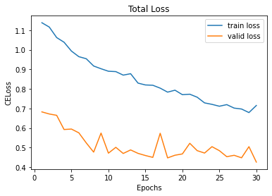

```python
epochs = np.arange(1, 31, 1)
plt.plot(epochs, total_loss_t, label='train loss')
plt.plot(epochs, total_loss_v, label='valid loss')
plt.title('Total Loss')
plt.xlabel('Epochs')
plt.ylabel('CELoss')
plt.legend();
```

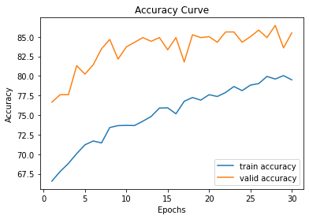

```python
epochs = np.arange(1, 31, 1)
plt.plot(epochs, train_acc, label='train accuracy')
plt.plot(epochs, valid_acc, label='valid accuracy')
plt.title('Accuracy Curve')
plt.xlabel('Epochs')
plt.ylabel('Accuracy')
plt.legend();
```

### (IMPLEMENTATION) Test the Model

Try out your model on the test dataset of dog images. Use the code cell below to calculate and print the test loss and accuracy. Ensure that your test accuracy is greater than 60%.

```python
test(loaders_transfer, model_transfer, criterion_transfer, use_cuda)
```

```
Test Loss: 0.502563


Test Accuracy: 85% (713/836)
```

### (IMPLEMENTATION) Predict Dog Breed with the Model

Write a function that takes an image path as input and returns the dog breed (`Affenpinscher`, `Afghan hound`, etc) that is predicted by your model.

```python
### TODO: Write a function that takes a path to an image as input
### and returns the dog breed that is predicted by the model.

# list of class names by index, i.e. a name can be accessed like class_names[0]
class_names = [item[4:].replace("_", " ") for item in sorted(os.listdir(train_dir))]

def predict_breed_transfer(img_path, model):
    ## load the image and return the predicted breed
    # Load in the image and convert to rgb
    img = Image.open(img_path).convert('RGB')

    # transforming image
    transform = transforms.Compose([transforms.Resize(256),
                                   transforms.CenterCrop(224),
                                   transforms.ToTensor(),
                                   transforms.Normalize(mean=[0.485, 0.456, 0.406],
                                                         std=[0.229, 0.224, 0.225])])
    img = transform(img)

    # move model to cuda if available
    if use_cuda:
        model = model.cuda()
        img = img.cuda()

    # Unsqueezing to add artificial dimension
    img = img.unsqueeze(0)

    # getting predictions, set model to evaluation
    model.eval()

    ### -------------------------------- ###
    ## Adding Functionality for dog mutts
    ### -------------------------------- ###
    pred = model(img)
    # getting the probabilites
    ps = torch.exp(pred)
    # sorting
    ps, idx = torch.sort(ps, descending=True)
    # detaching and unpacking lists
    ps = ps.detach().cpu().numpy()
    idx = idx.detach().cpu().numpy()
    ps, idx = ps[0], idx[0]
    # setting thresholds
    thresh_1, thresh_2 = 0.65, 0.35
    thresh_3, thresh_4 = 0.45, 0.15
    # for two breed mutts
    if ps[0] < thresh_1 and ps[1] > thresh_2:
        mutt_1 = class_names[idx[0]]
        mutt_2 = class_names[idx[1]]
        return "Wow!... You're a Mutt!\nYour ancestors might be: " + str(mutt_1) + " + "\
         + str(mutt_2)
    # for three breed mutts
    elif ps[0] < thresh_3 and ps[1] > thresh_4 and ps[2] > thresh_4:
        mutt_1 = class_names[idx[0]]
        mutt_2 = class_names[idx[1]]
        mutt_3 = class_names[idx[2]]
        return "Wow!... You're a Mutt!\nYour ancestors might be: " + str(mutt_1) + " + "\
         + str(mutt_2) + " + " + str(mutt_3)
    else:
        predicted_breed = class_names[idx[0]]
        return predicted_breed
```

## **Writing a function to overlay dog filters in detected human images**

```python
# Defining Model Architecture
# Here, we are going to use CNNs
import torch.nn as nn
import torch.nn.functional as F
from torchsummary import summary

class Net(nn.Module):

  def __init__( self ):
    super( Net, self ).__init__()

    # Defining layers of the CNN
    self.conv1 = nn.Conv2d(3, 16, 3, padding=1)
    self.conv2 = nn.Conv2d(16, 32, 3, padding=1)
    self.conv3 = nn.Conv2d(32, 64, 3, padding=1)
    self.conv4 = nn.Conv2d(64, 128, 3, padding=1)
    self.conv5 = nn.Conv2d(128, 256, 3, padding=1)

    # max pooling layer
    self.pool = nn.MaxPool2d(2,2)

    # Linear layer
    self.fc1 = nn.Linear(256 * 3 * 3, 4096)
    self.fc2 = nn.Linear(4096, 2048)
    #self.fc3 = nn.Linear(1024, 500)
    self.predict = nn.Linear(2048, 30)


    # Batch Norm conv
    self.conv1_bn = nn.BatchNorm2d(16)
    self.conv2_bn = nn.BatchNorm2d(32)
    self.conv3_bn = nn.BatchNorm2d(64)
    self.conv4_bn = nn.BatchNorm2d(128)
    self.conv5_bn = nn.BatchNorm2d(256)

    # Batch Norm linear
    self.fc1_bn = nn.BatchNorm1d(4096)
    self.fc2_bn = nn.BatchNorm1d(2048)
    #self.fc3_bn = nn.BatchNorm1d(500)

    # Droupout Layer
    self.dropout = nn.Dropout(0.5)

  def forward( self, x ):
    ## Define forward behavior
    x = self.pool(F.leaky_relu(self.conv1_bn(self.conv1(x))))
    x = self.pool(F.leaky_relu(self.conv2_bn(self.conv2(x))))
    x = self.pool(F.leaky_relu(self.conv3_bn(self.conv3(x))))
    x = self.pool(F.leaky_relu(self.conv4_bn(self.conv4(x))))
    x = self.pool(F.leaky_relu(self.conv5_bn(self.conv5(x))))

    # flatten image input
    x = x.view(-1, 256 * 3 * 3 )

    # add 1st hidden layer, with relu activation function
    x = F.leaky_relu( self.fc1_bn(self.fc1(x)) )
    x = self.dropout(x)
    # add 2nd hidden layer, with relu activation function
    x = F.leaky_relu( self.fc2_bn(self.fc2(x)) )
    x = self.dropout(x)
    # add 3rd hidden layer
    x = self.predict(x)
    return x

# Instantiate the model
facial_model = Net()
use_cuda = torch.cuda.is_available()
if use_cuda:
  facial_model.cuda()
summary(facial_model, (3, 96, 96))
```

```
----------------------------------------------------------------
        Layer (type)               Output Shape         Param #
================================================================
            Conv2d-1           [-1, 16, 96, 96]             448
       BatchNorm2d-2           [-1, 16, 96, 96]              32
         MaxPool2d-3           [-1, 16, 48, 48]               0
            Conv2d-4           [-1, 32, 48, 48]           4,640
       BatchNorm2d-5           [-1, 32, 48, 48]              64
         MaxPool2d-6           [-1, 32, 24, 24]               0
            Conv2d-7           [-1, 64, 24, 24]          18,496
       BatchNorm2d-8           [-1, 64, 24, 24]             128
         MaxPool2d-9           [-1, 64, 12, 12]               0
           Conv2d-10          [-1, 128, 12, 12]          73,856
      BatchNorm2d-11          [-1, 128, 12, 12]             256
        MaxPool2d-12            [-1, 128, 6, 6]               0
           Conv2d-13            [-1, 256, 6, 6]         295,168
      BatchNorm2d-14            [-1, 256, 6, 6]             512
        MaxPool2d-15            [-1, 256, 3, 3]               0
           Linear-16                 [-1, 4096]       9,441,280
      BatchNorm1d-17                 [-1, 4096]           8,192
          Dropout-18                 [-1, 4096]               0
           Linear-19                 [-1, 2048]       8,390,656
      BatchNorm1d-20                 [-1, 2048]           4,096
          Dropout-21                 [-1, 2048]               0
           Linear-22                   [-1, 30]          61,470
================================================================
Total params: 18,299,294
Trainable params: 18,299,294
Non-trainable params: 0
----------------------------------------------------------------
Input size (MB): 0.11
Forward/backward pass size (MB): 5.05
Params size (MB): 69.81
Estimated Total Size (MB): 74.96
----------------------------------------------------------------
```

```python
from torchvision.transforms import transforms

class ToTensor(object):

  def __call__(self, image):
    # imagem numpy: C x H x W
    # imagem torch: C X H X W

    image = image.transpose((0, 1, 2))
    return torch.from_numpy(image)

class DuplicateArray(object):

  def __call__(self, image):
    image = image.repeat(3, axis=0)
    return image


mean = np.array([0.485, 0.456, 0.406])
std  = np.array([0.229, 0.224, 0.225])

def denormalize(image, mean=mean, std=std):
  inp = image.transpose((1, 2, 0))
  img = std * inp + mean
  return img

transform = transforms.Compose([
                                DuplicateArray(),
                                ToTensor(),
                                transforms.Normalize(mean, std)])
```

```python
def predict(img):

  if use_cuda:
    face_model = facial_model.cuda()
    img = Variable(img.float().cuda())

  # img = Variable(torch.from_numpy(img))
  # model = model2
  face_model.eval()

  prediction = face_model(img)
  prediction = prediction.detach().cpu().numpy()

  if len(prediction) > 0:
    return prediction
```

```python
from torch.autograd import Variable


facial_model.load_state_dict(torch.load('/content/drive/MyDrive/Udacity-Intro to Pytorch/\
Convolutional Neural Networks/project-dog-classification/facial_keypoints_detection/model.pt'))

def transparentOverlay(src , overlay , pos=(0,0),scale = 1):
    overlay = cv2.resize(overlay,(0,0),fx=scale,fy=scale)
    h,w,_ = overlay.shape  # Size of foreground
    rows,cols,_ = src.shape  # Size of background Image
    y,x = pos[0],pos[1]    # Position of foreground/overlay image

    #loop over all pixels and apply the blending equation
    for i in range(h):
        for j in range(w):
            if x+i >= rows or y+j >= cols:
                continue
            alpha = float(overlay[i][j][3]/255.0) # read the alpha channel
            src[x+i][y+j] = alpha*overlay[i][j][:3]+(1-alpha)*src[x+i][y+j]
    return src

def get_filter_spots(pred_res, scale_x, scale_y, scale, dog_filter):
    #scale_x and y for scale of 96x96 image and scale for  overall filter scaling
    filter_nose = dog_filter['nose']
    filter_right_ear = dog_filter['ear_right']

    #Hyper-Paramaters
    y_padding = 5
    ear_padding = 6

    #Add nose
    nose_x = int(pred_res[20]*48+48*scale_x - filter_nose.shape[1]*scale/2)
    nose_y = int( (pred_res[21]*48+48 + y_padding)*scale_y - filter_nose.shape[0]*scale/2)

    #result = transparentOverlay(img_crop.copy(),filter_nose,(x,y),scale)

    left_ear_x = 0 - ear_padding
    left_ear_y = 0 - ear_padding*2

    right_ear_x = int( (96 + ear_padding*2)*scale_x - filter_right_ear.shape[0]*scale )
    right_ear_y = (0 - ear_padding)*scale_y

    return [nose_x, nose_y],[left_ear_x*scale_x, left_ear_y*scale_y],[right_ear_x, right_ear_y]

def get_best_scaling(w):
    filter_width = 420
    return 1.1*(w/filter_width)


def get_eye_angle(pred):
    left = pred[0:1]
    right = pred[2:3]
    #find vector
    vec = [right[0]-left[0], right[1]-left[1] ]
    angle = vec[0] / (math.sqrt(vec[0]*vec[0] + vec[1]*vec[1]))

    return angle

# Function to apply dog filter
def add_dog_filter(img_path, dog_filter):
    # load color (BGR) image
    img = cv2.imread( img_path )
    # convert BGR image to grayscale
    gray = cv2.cvtColor( img, cv2.COLOR_BGR2GRAY )

    # find faces in image
    faces = face_cascade.detectMultiScale( gray )

    filter_nose = dog_filter['nose']
    filter_left_ear = dog_filter['ear_left']
    filter_right_ear = dog_filter['ear_right']

    if len(faces)==0:
        print("No faces Detected in the image")
        return cv2.cvtColor(img, cv2.COLOR_BGR2RGB)

    for (x,y,w,h) in faces:
        # add bounding box to color image
        #cv2.rectangle(img,(x,y),(x+w,y+h),(255,0,0),2)

        img_crop = img[y:y+h, x:x+w]

        scale_x = img_crop.shape[0]/96
        scale_y = img_crop.shape[1]/96

        img2 = cv2.resize(img_crop, (96,96))
        img2 = cv2.cvtColor(img2, cv2.COLOR_BGR2GRAY)
        #print(img2.shape)

        #for model
        img2 = np.vstack(img2)
        img2 = img2 / 255.  # scale pixel values to [0, 1]
        img2 = img2.astype(np.float32)
        img2 = img2.reshape(-1, 96, 96)
        #print(img2.shape)
        img2 = transform(img2)
        img2 = img2.unsqueeze(0)
        #print(img2.shape)


        #Predict using CNN model
        pred_res = predict(img2)[0]

        scale = get_best_scaling(w)

        nose, left_ear,right_ear = get_filter_spots(pred_res, scale_x, scale_y, scale, dog_filter)

        #Add images
        result = transparentOverlay(img.copy(),filter_nose,( int(nose[0]+x), int(nose[1]+y)), scale)
        result = transparentOverlay(result.copy(),filter_left_ear,( int(left_ear[0]+x), int(left_ear[1]+y)), scale)
        result = transparentOverlay(result.copy(),filter_right_ear,( int(right_ear[0]+x), int(right_ear[1]+y)), scale)

        img = result
    #Change to RGB
    result = cv2.cvtColor(result, cv2.COLOR_BGR2RGB)
    #and return
    return result
```

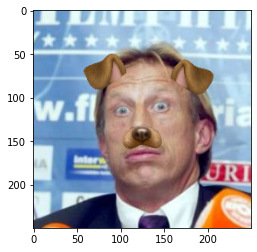

```python
#### Testing filter Algorithm
#read filter image
filter_path = '/content/drive/MyDrive/\
Udacity-Intro to Pytorch/Convolutional Neural Networks/project-dog-classification/dog_filter/filter3.png'
filter_full = cv2.imread(filter_path, cv2.IMREAD_UNCHANGED) #Read woth PNG transparency

dog_filter = {  'nose' : filter_full[302:390,147:300],
                'ear_left' : filter_full[55:195,0:160],
                'ear_right' : filter_full[55:190,255:420],
             }

img_path = human_files[62]
result = add_dog_filter(img_path, dog_filter)

plt.imshow(result)
plt.show()
result = cv2.cvtColor(result, cv2.COLOR_RGB2BGR)
```

## Step 5: Write your Algorithm

Write an algorithm that accepts a file path to an image and first determines whether the image contains a human, dog, or neither. Then,

- if a **dog** is detected in the image, return the predicted breed.
- if a **human** is detected in the image, return the resembling dog breed.
- if **neither** is detected in the image, provide output that indicates an error.

You are welcome to write your own functions for detecting humans and dogs in images, but feel free to use the `face_detector` and `human_detector` functions developed above. You are **required** to use your CNN from Step 4 to predict dog breed.

Some sample output for our algorithm is provided below, but feel free to design your own user experience!

[figure not shown]

### (IMPLEMENTATION) Write your Algorithm

```python
### TODO: Write your algorithm.
### Feel free to use as many code cells as needed.
def run_app(img_path):
    VGG16 = models.vgg16(pretrained=True)
    ## handle cases for a human face, dog, and neither

    image = Image.open(img_path)
    # checks for human faces in image
    has_face = face_detector(img_path)
    # Checks for dog in image
    is_dog = dog_detector(img_path, VGG16)
    breed = predict_breed_transfer( img_path, model_transfer )

    if has_face:
        print('hello human!')
        overlay = add_dog_filter(img_path, dog_filter)
        plt.imshow( overlay )
        plt.show()
        print('You look like the "' + breed + '" dog breed!')

    elif is_dog:
        print('hello dog!')
        plt.imshow(image)
        plt.show()
        print('Your predicted breed is uumm...........\n', breed)

    elif not has_face and not is_dog:
        print('Oh dear.....\n')
        plt.imshow(image)
        plt.show()
        print('This image has neither a dog or human in it!\n')
```

## Step 6: Test Your Algorithm

In this section, you will take your new algorithm for a spin! What kind of dog does the algorithm think that *you* look like? If you have a dog, does it predict your dog's breed accurately? If you have a cat, does it mistakenly think that your cat is a dog?

### (IMPLEMENTATION) Test Your Algorithm on Sample Images!

Test your algorithm at least six images on your computer. Feel free to use any images you like. Use at least two human and two dog images.

**Question 6:** Is the output better than you expected :) ? Or worse :( ? Provide at least three possible points of improvement for your algorithm.

**Answer:** (Three possible points for improvement)

> The output is better than I expected.
> - The algorithm could train for longer to improve results.
> - Better image augmentation to train a more robust classifier.
> - Horizontal voting deep learning ensemble may be helpful.

```
hello human!
```

[figure not shown]

```
You look like the "Chinese crested" dog breed!

hello human!
```

[figure not shown]

```
You look like the "Dachshund" dog breed!

hello human!
```

[figure not shown]

```
You look like the "Dachshund" dog breed!

hello dog!
```

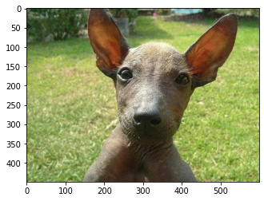

```
Your predicted breed is uumm...........
 Xoloitzcuintli

hello dog!
```

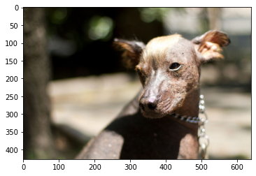

```
Your predicted breed is uumm...........
 Italian greyhound

hello dog!
```

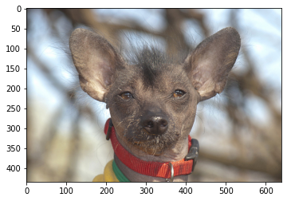

```
Your predicted breed is uumm...........
 Xoloitzcuintli
```

```python
## TODO: Execute your algorithm from Step 6 on
## at least 6 images on your computer.
## Feel free to use as many code cells as needed.

## suggested code, below
for file in np.hstack((human_files[:3], dog_files[:3])):
    run_app(file)
    print()
```

```
hello dog!
```

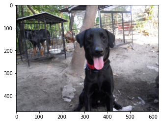

```
Your predicted breed is uumm...........
 Labrador retriever

hello dog!
```

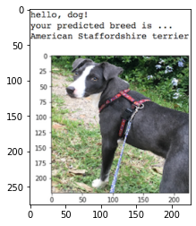

```
Your predicted breed is uumm...........
 American staffordshire terrier

hello dog!
```

[figure not shown]

```
Your predicted breed is uumm...........
 Irish red and white setter

hello dog!
```

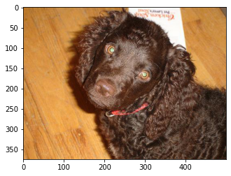

```
Your predicted breed is uumm...........
 American water spaniel

hello dog!
```

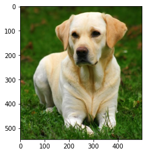

```
Your predicted breed is uumm...........
 Labrador retriever

hello dog!
```

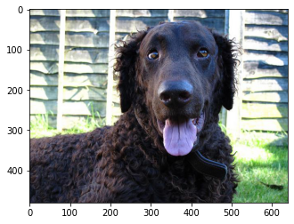

```
Your predicted breed is uumm...........
 Curly-coated retriever

Oh dear.....
```

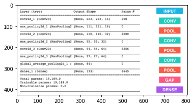

```
This image has neither a dog or human in it!


hello dog!
```

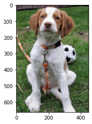

```
Your predicted breed is uumm...........
 Brittany

hello dog!
```

[figure not shown]

```
Your predicted breed is uumm...........
 Wow!... You're a Mutt!
Your ancestors might be: Chesapeake bay retriever + Labrador retriever

hello human!
```

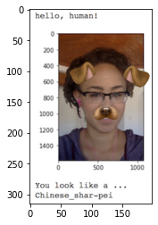

```
You look like the "Silky terrier" dog breed!
```

```python
path = "/content/drive/My Drive/Udacity-Intro to \
Pytorch/Convolutional Neural Networks/project-dog-classification/images/*"
test_imgs = np.array(glob(path))
for img_pth in test_imgs:
    run_app(img_pth)
    print()
```

```
hello dog!
```

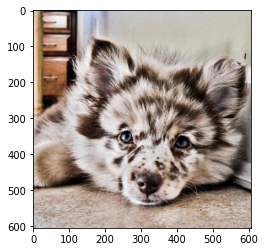

```
Your predicted breed is uumm...........
 Wow!... You're a Mutt!
Your ancestors might be: Akita + Australian shepherd

hello dog!
```

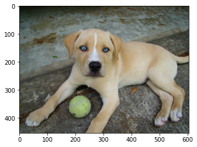

```
Your predicted breed is uumm...........
 Labrador retriever

hello dog!
```

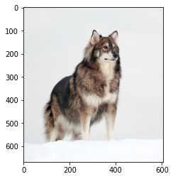

```
Your predicted breed is uumm...........
 Alaskan malamute

hello dog!
```

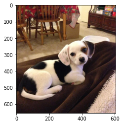

```
Your predicted breed is uumm...........
 Beagle

hello dog!
```

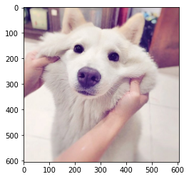

```
Your predicted breed is uumm...........
 Wow!... You're a Mutt!
Your ancestors might be: Norwegian buhund + American eskimo dog + Canaan dog
```

```python
path = "/content/drive/My Drive/Udacity-Intro to \
Pytorch/Convolutional Neural Networks/project-dog-classification/dog_mutts/*"
test_mutts = np.array(glob(path))
for img_pth in test_mutts[:5]:
    run_app(img_pth)
    print()
```